# PowerPoint presentations generation

Source: [`vignettes/offcran/powerpoint.Rmd`](https://github.com/davidgohel/officer/blob/master/vignettes/offcran/powerpoint.Rmd)

```r
library(officer)
```

The main functions for PowerPoint generatiion are presented below:

[figure not shown]

## Initialize

Use the function `read_pptx()` to create an R object representing a PowerPoint document. The initial PowerPoint file can be specified with the `path` argument. If none is provided, this file will be an empty document located in the package directory. Formats and available slide layouts will be those available in the template file. The content of original document is also preserved (but can be manipulated, i.e. delete a slide).

```r
my_pres <- read_pptx()
```

## Add slides

To add a new slide, use the function `add_slide()`. It requires 3 arguments:

- an rpptx object
- a slide layout name
- a master layout name

```r
# my_pres <- add_slide(my_pres, layout = "Title Only", master = "Office Theme")
# my_pres <- add_slide(my_pres, layout = "Two Content", master = "Office Theme")
my_pres <- add_slide(my_pres, layout = "Title and Content", master = "Office Theme")
```

**Note that the `layout` and `master` values must match values from the initial document.**

Layout names and master layout names are not easily *readable* within PowerPoint, but these can be read easily with the function `layout_summary()`.

```r
layout_summary(my_pres)
```

| layout | master |
| --- | --- |
| Title Slide | Office Theme |
| Title and Content | Office Theme |
| Section Header | Office Theme |
| Two Content | Office Theme |
| Comparison | Office Theme |
| Title Only | Office Theme |
| Blank | Office Theme |

## Add content to a slide

Content must be placed on a slide in a new shape.

`ph_with()` is the unique function you should have to use to add content to a slide. It has 3 arguments, the `rpptx` object, the object to be printed and the location that define the placeholder where shape will be created.

> Note that `ph_with` is to be used instead of functions `ph_with_*` and `ph_with_*_at`.

```r
my_pres <- ph_with(my_pres, value = "Hello world", location = ph_location_type(type = "title"))
my_pres <- ph_with(my_pres, value = "A footer", location = ph_location_type(type = "ftr"))
my_pres <- ph_with(my_pres, value = format(Sys.Date()), location = ph_location_type(type = "dt"))
my_pres <- ph_with(my_pres, value = "slide 1", location = ph_location_type(type = "sldNum"))
my_pres <- ph_with(my_pres, value = head(letters), location = ph_location_type(type = "body"))
```

## Write the PowerPoint file

The (updated) Powerpoint file can be generated using the `print()` function along with the `target` argument:

```r
print(my_pres, target = "first_example.pptx")
```

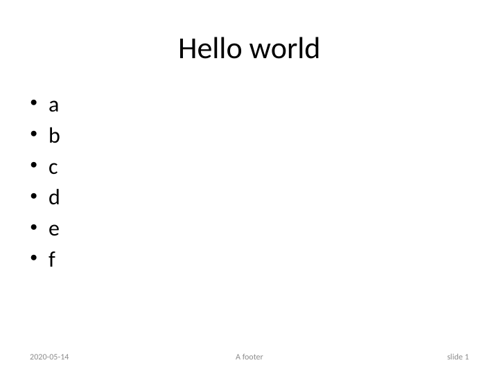

## Content location

The function `ph_with()` is expecting an argument `location` that will be used to specify the location of the new shape.

This argument must be an object created from a call to one of the `ph_location*` functions (*placeholder location*). There are several `ph_location*` functions: `ph_location_type()`, `ph_location_fullsize()`, `ph_location_label()`, `ph_location_left()`, `ph_location_right()`, `ph_location_template()` and `ph_location()`.

The following code adds text “Hello world” in a new shape.

That shape will inherit its properties from the placeholder that has type `body`. This is defined in the slide layout used by the slide, i.e. `Title and Content` in our example.

```r
doc <- read_pptx()
doc <- add_slide(doc)
doc <- ph_with(doc, c("Hello world", "Bonjour monde", "Blah blah blah"),
          location = ph_location_type(type = "body") )

print(doc, target = "ph_with_location_type.pptx")
```

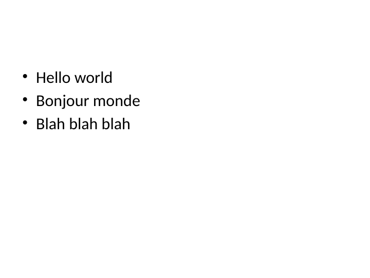

The following example will print few rows of `iris` data.frame in a new shape. That shape will inherit its properties from the placeholder that has label `Content Placeholder 2`.

This is defined in the slide layout used by the slide, i.e. `Title and Content` in our example. Call `layout_properties()` to see available placeholder names (see column `ph_label`.

```r
mypres <- read_pptx()
mypres <- add_slide(mypres, layout = "Title and Content", master = "Office Theme")
layout_properties ( x = mypres, layout = "Title and Content" )
```

|  | master_name | name | type | id | ph_label | ph | offx | offy | cx | cy |
| --- | --- | --- | --- | --- | --- | --- | --- | --- | --- | --- |
| 5 | Office Theme | Title and Content | body | 3 | Content Placeholder 2 |  | 0.500000 | 1.7500000 | 9.000000 | 4.9496533 |
| 10 | Office Theme | Title and Content | dt | 4 | Date Placeholder 3 |  | 0.500000 | 6.9513889 | 2.333333 | 0.3993056 |
| 21 | Office Theme | Title and Content | ftr | 5 | Footer Placeholder 4 |  | 3.416667 | 6.9513889 | 3.166667 | 0.3993056 |
| 25 | Office Theme | Title and Content | sldNum | 6 | Slide Number Placeholder 5 |  | 7.166667 | 6.9513889 | 2.333333 | 0.3993056 |
| 31 | Office Theme | Title and Content | title | 2 | Title 1 |  | 0.500000 | 0.3003478 | 9.000000 | 1.2500000 |

```r
mypres <- ph_with(mypres, head(iris),
  location = ph_location_label(
    ph_label = "Content Placeholder 2") )

mypres <- ph_with(mypres, "Slide title",
          location = ph_location_label(
    ph_label = "Title 1") )

print(mypres, target = "ph_with_location.pptx")
```

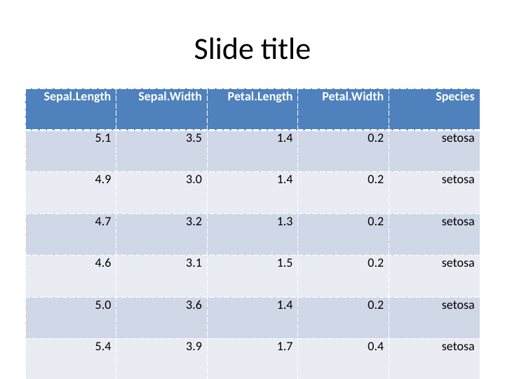

This example add a new slide with layout “Two Content” and prints sets of paragraphs of text in two new shapes, one representing the left side and one representing the right side.

```r
mypres <- add_slide(mypres, layout = "Two Content")
mypres <- ph_with(mypres, sprintf("text item #%d", 1:6),
          location = ph_location_left())
mypres <- ph_with(mypres, sprintf("text item #%d", 7:12),
          location = ph_location_right())

print(mypres, target = "ph_with_location.pptx")
```

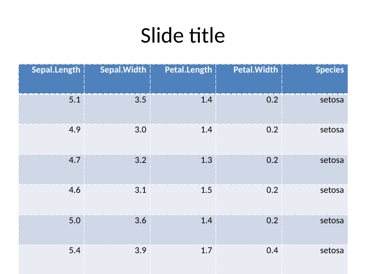

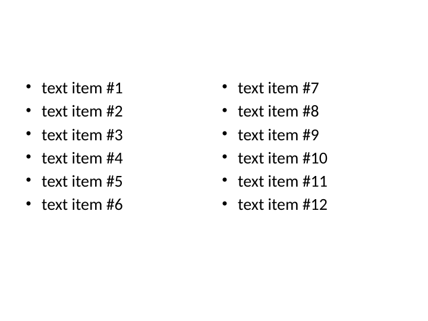

## Supported contents

The following types of content are supported:

- vectors of text, numeric and factor
- block_list, unordered_list when formatting is complex
- data.frame
- ggplot objects
- external_img
- [flextable::flextable](https://davidgohel.github.io/flextable)
- [rvg::dml](https://cran.r-project.org/package=rvg)

### Text and vectors

```r
doc <- read_pptx()
doc <- add_slide(doc, layout = "Two Content", master = "Office Theme")
doc <- ph_with(doc, value = pi, location = ph_location_type(type = "title") )
doc <- ph_with(doc, value = as.factor(letters[1:2]), location = ph_location_type(type = "ftr") )
doc <- ph_with(doc, value = c("one blah", "two blah"), location = ph_location_left() )
doc <- ph_with(doc, value = c("three blah", "four blah"), location = ph_location_right() )
print(doc, target = "ph_with_vectors.pptx")
```

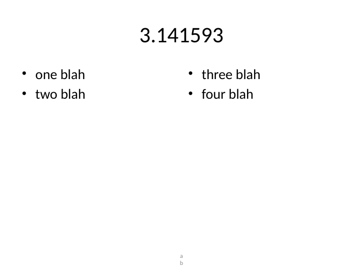

### data.frame

```r
doc <- read_pptx()
doc <- add_slide(doc)
doc <- ph_with(x = doc, value = head(iris),
   location = ph_location_type(type = "body") )
print(doc, target = "ph_with_df.pptx")
```

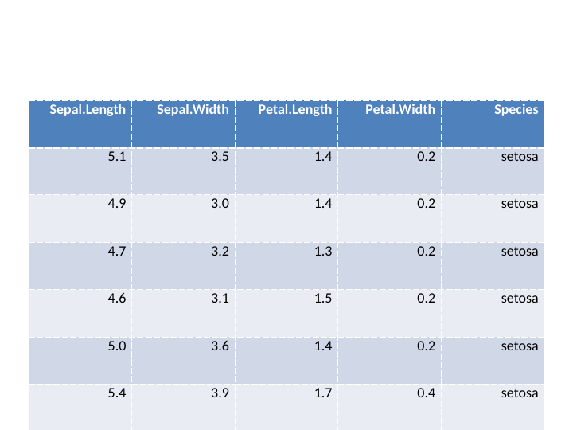

### ggplot objects

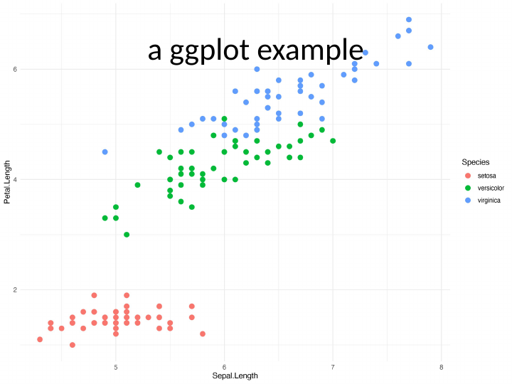

```r
library(ggplot2)
gg_plot <- ggplot(data = iris ) +
  geom_point(
    mapping = aes(Sepal.Length, Petal.Length, color = Species),
    size = 3) + theme_minimal()

doc <- read_pptx()
doc <- add_slide(doc)
doc <- ph_with(x = doc, value = gg_plot,
               location = ph_location_fullsize() )
doc <- ph_with(x = doc, "a ggplot example",
               location = ph_location_type(
                 type = "title") )
print(doc, target = "ph_with_gg.pptx")
```

### Images

> see wrapper function named `external_img()`

```r
img.file <- file.path( R.home("doc"), "html", "logo.jpg" )

doc <- read_pptx()
doc <- add_slide(doc)
doc <- ph_with(x = doc, external_img(img.file, width = 1.39, height = 1.06),
   location = ph_location_type(type = "body"), use_loc_size = FALSE )
print(doc, target = "ph_with_img.pptx")
```

[figure not shown]

### flextable

```r
library(flextable)
ft <- flextable(head(mtcars))
ft <- autofit(ft)
doc <- read_pptx()
doc <- add_slide(doc)
doc <- ph_with(x = doc, ft,
   location = ph_location_type(type = "body") )
print(doc, target = "flextable.pptx")
```

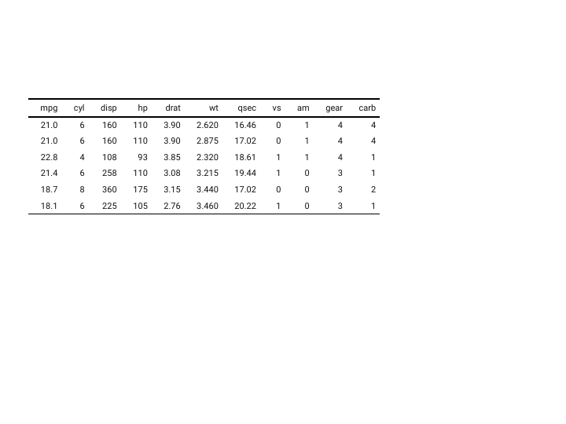

### Editable graphics (rvg)

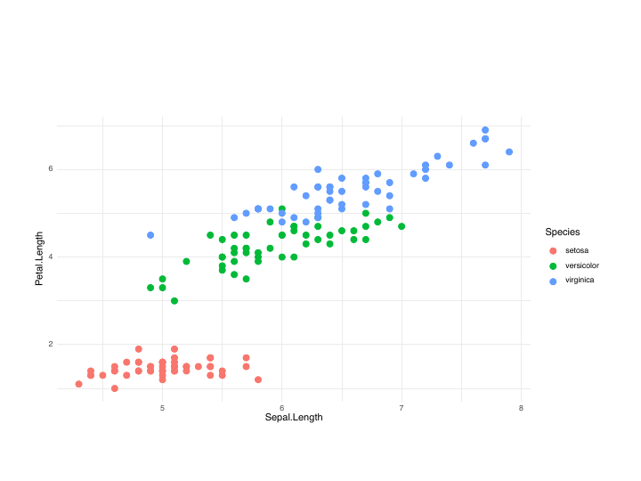

```r
library(rvg)
editable_graph <- dml(ggobj = gg_plot)
doc <- read_pptx()
doc <- add_slide(doc)
doc <- ph_with(x = doc, editable_graph,
   location = ph_location_type(type = "body") )
print(doc, target = "rvg.pptx")
```

### Multiple paragraphs

> see wrapper function named `block_list()`

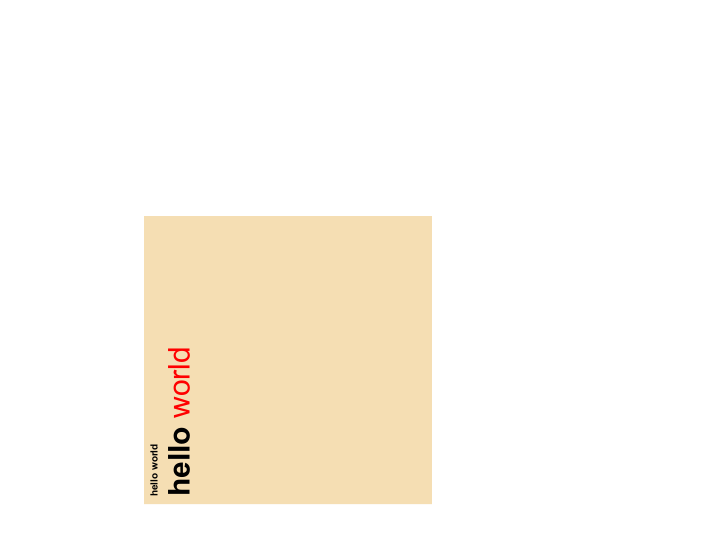

```r
# first define a block_list made of fpar ----
bl <- block_list(
  fpar(ftext("hello world", fp_text(bold = TRUE))),
  fpar(
    ftext("hello", fp_text(bold = TRUE, font.size = 30)),
    ftext(" world", prop = fp_text(color = "red", font.size = 30) )
  )
)

doc <- read_pptx()
doc <- add_slide(doc)
doc <- ph_with(x = doc, value = bl,
               location = ph_location(label = "my_name",
                 left = 2, top = 3, width = 4, height = 4,
                 bg = "wheat", rotation = 90)
       )

print(doc, target = "ph_with_block_list.pptx")
```

### Single paragraph

> see wrapper function named `fpar()` (a `block_list` is made of `fpar` objects)

```r
# first define a fpar ----
fp <- fpar(
    ftext("hello", fp_text(bold = TRUE, font.size = 40)),
    ftext(" world", prop = fp_text(color = "red", font.size = 40) )
  )

doc <- read_pptx()
doc <- add_slide(doc)
doc <- ph_with(x = doc, value = fp,
               location = ph_location_type(type = "title")
       )

print(doc, target = "ph_with_fpar.pptx")
```

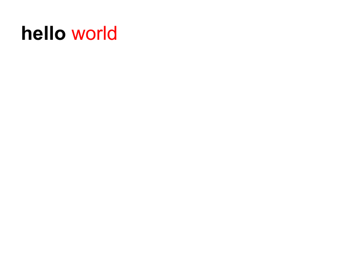

### Unordered lists

> See wrapper function named `unordered_list()`

```r
doc <- read_pptx()

ul <- unordered_list(
  level_list = c(1, 2, 2, 3, 3, 1),
  str_list = c("Level1", "Level2", "Level2", "Level3", "Level3", "Level1"),
  style = fp_text(color = "red", font.size = 0) )

doc <- add_slide(doc)
doc <- ph_with(x = doc, value = ul,
               location = ph_location_type(type = "body") )

print(doc, target = "ph_with_ul.pptx")
```

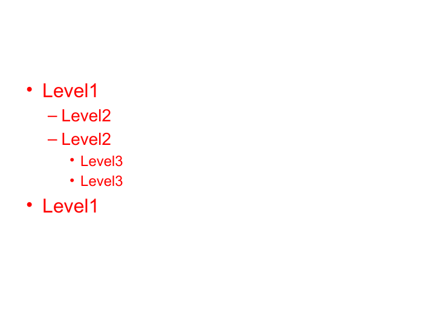

## Slide selection and manipulation

`add_slide()` is not the only function to let you manipulate slides:

- `remove_slide()`
- `move_slide()`
- `on_slide()`.

```r
my_pres <- read_pptx()
my_pres <- add_slide(my_pres, layout = "Title Only")
my_pres <- ph_with(my_pres, value = "Slide 1", location = ph_location_type(type = "title"))
my_pres <- add_slide(my_pres, layout = "Two Content")
my_pres <- ph_with(my_pres, value = "Slide 2", location = ph_location_type(type = "title"))
my_pres <- add_slide(my_pres, layout = "Title and Content")
my_pres <- ph_with(my_pres, value = "Slide 3", location = ph_location_type(type = "title"))
```

A slide can be moved with the `move_slide()` function.

```r
my_pres <- move_slide(my_pres, index = 1, to = 3)
print(my_pres, target = "slide_manip.pptx")
```

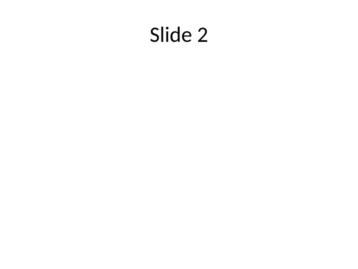

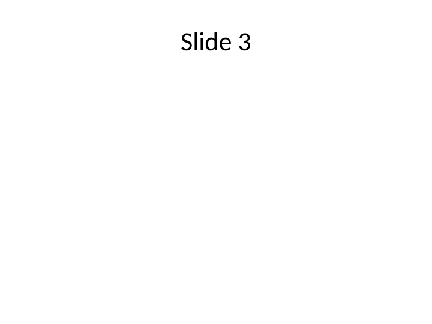

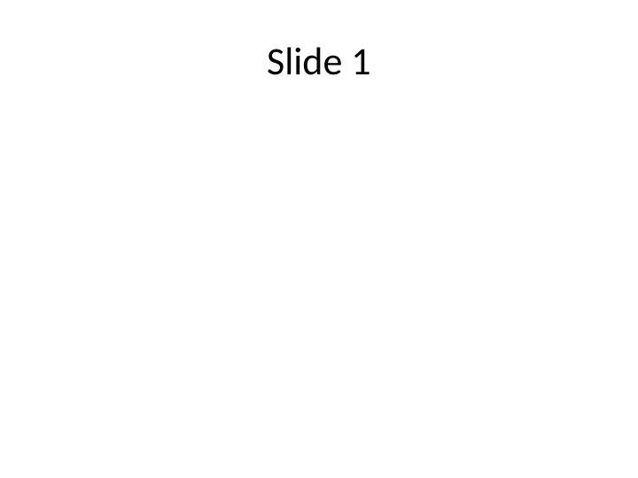

A slide can be removed with the `remove_slide()` function.

```r
my_pres <- remove_slide(my_pres, index = 1)
print(my_pres, target = "slide_manip.pptx")
```

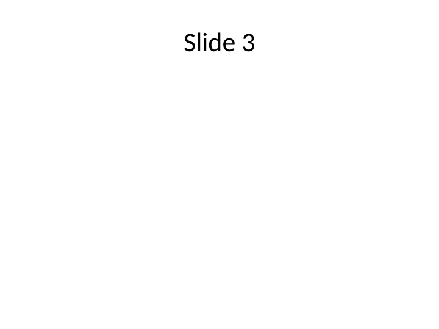

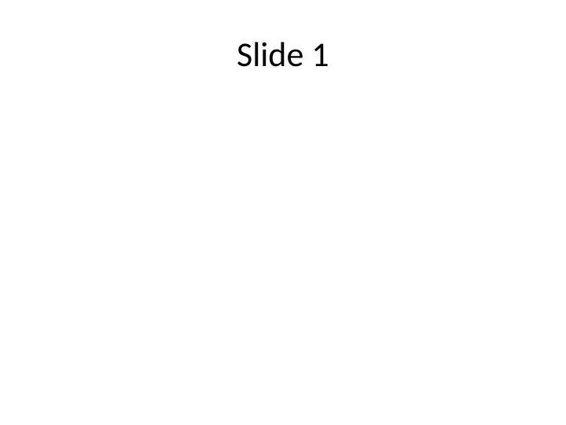

A slide can be selected with the `on_slide()` function.

```r
my_pres <- on_slide(my_pres, index = 1)
```

## Remove content from a slide

Use `slide_summary()` to easily identify shapes in the slide that can be removed.

```r
slide_summary(doc)
```

| type | id | ph_label | offx | offy | cx | cy | text |
| --- | --- | --- | --- | --- | --- | --- | --- |
| body | 2 | Content Placeholder 2 | 0.5 | 1.75 | 9 | 4.949653 | Level1Level2Level2Level3Level3Level1 |

In the following example, the shape corresponding to `type "body"` will be removed from the current slide:

```r
doc <- ph_remove(x = doc, type = "body", id = 1)
```

## Miscellaneous

### External links

`ph_hyperlink()` adds a hyperlink to an existing placeholder in the current slide. The argument `href` should contain a valid URL (i.e. starting with `http(s)`).

```r
doc <- read_pptx()
doc <- add_slide(doc)
doc <- ph_with(doc, "Blah blah blah", location = ph_location_type(type = "body"))
doc <- ph_hyperlink(doc,
  ph_label = "Content Placeholder 2", href = "https://cran.r-project.org")
```

### Internal links

`ph_slidelink()` adds an internal link into an existing placeholder. The argument `slide_index` should contain the index of the target slide.

```r
doc <- read_pptx()
doc <- add_slide(doc)
doc <- ph_with(doc, "Blah blah blah", location = ph_location_type(type = "body"))
doc <- add_slide(doc)
doc <- ph_with(doc, "placeholder target", location = ph_location_type(type = "title"))
doc <- on_slide(doc, index = 1 )
doc <- ph_slidelink(doc,
  ph_label = "Content Placeholder 2", slide_index = 2)
```

## Resources

Len Kiefer wrote two very good blog posts about officer, he is providing nice examples with the corresponding R code:

- http://lenkiefer.com/2017/09/23/crafting-a-powerpoint-presentation-with-r/
- http://lenkiefer.com/2017/09/27/use-purrr/

[Eric Nanz](https://r-podcast.org) gave a short presentation about using officer in the Advanced R Markdown workshop held at the 2019 RStudio conference:

- https://rpodcast.github.io/officer-advrmarkdown/